# Circular GLMM Summary: Bimodal Dances at Low Solar Elevations

James Foster

2026-10-20

# Details

**DESCRIPTION**

Load and plot the circular mixture GLMM fitted in `HS_circGLMM_mixture_lowel.ipynb` to describe waggle-run angles relative to the feeder for dances in the vertical and horizontal conditions at low solar elevations (`sun_el` $< 15°$, the hour before sunset). The model to summarise is set by `params$model_file` (by default, the condition-dependent mixture, `2Results/unwrap_models/HS_lowel_VH_2_axial_wH.nc`), and the models to compare are found in `params$model_dir`.

**INPUTS**

`HS_functions.R`, `0Data/hs_dance_reorg.csv`, `0Data/hs_dance_lowel_VH.feather`, `2Results/unwrap_models/HS_lowel_VH_*.nc`

**OUTPUTS**

Plotted estimates, predictions and contrasts.

**REFERENCES**

**modelling methods**

- Sayin S, … Graving JM, $\textit{et~al}$.(2025) The behavioral mechanisms governing collective motion in swarming locusts. $\textit{Science}$ 387,995-1000 [DOI:10.1126/science.adq7832](https://doi.org/10.1126/science.adq7832)
- Graving JM, Sayin S, Costelloe BR, Goldshtein A & Foster JJ. Unwrapping circular statistics with Bayesian multilevel models.
- Capretto, T., Piho, C., Kumar, R., Westfall, J., Yarkoni, T., & Martin, O.
  2022. `Bambi`: A simple interface for fitting Bayesian linear models in Python. *Journal of Statistical Software* 103(15), 1-29. doi:10.18637/jss.v103.i15
- Seyboldt, A., Carlson, E. L., & Carpenter, B. (2026). Preconditioning Hamiltonian Monte Carlo by minimizing Fisher Divergence. *arXiv* preprint arXiv:2603.18845.
- Stephens, M. (2000). Dealing with label switching in mixture models. *Journal of the Royal Statistical Society B* 62(4), 795-809.

# Motivation

At low solar elevations, dances on a horizontal comb are often bimodal, with waggle runs in two roughly opposite directions, whereas dances on a vertical comb remain unimodal. To describe these dances, each waggle run is modelled as a mixture of two von Mises distributions with opposite means and a shared concentration:

$$f(\theta \mid \mu, \kappa, w) = w\,\mathcal{M}(\theta \mid \mu, \kappa)
+ (1-w)\,\mathcal{M}(\theta \mid \mu + \pi, \kappa)$$

where $w$ is the proportion of waggle runs in the primary mode ($\mu$): $w = 1$ is unimodal, $w = 0.5$ is axially symmetric, and $w = 0$ is unimodal but reversed. Bimodality is summarised by $B = 1 - |2w - 1|$, which is 0 for a unimodal distribution (in either direction) and 1 for an axially symmetric one.

The model fitted was:

$\mu \sim$ H + (1 |Individual) + (1 |Dance)

$\kappa \sim$ H + (1 |Individual) + (1 |Dance)

$w \sim$ H + (1 |Individual) + (1 |Dance)

where the vertical condition is the reference (Intercept) and H is the effect of horizontal orientation (horizontal − vertical). Each dance was performed in a single condition, so dances (nested within individuals) have random intercepts only.

Two features of the priors make the two modes identifiable:

- individual and dance offsets in $\mu$ are Normal (unwrapped), so that a reversed dance is explained by a low $w$, rather than a 180° shift in $\mu$;
- $\text{logit}(w) > 0$ for the reference (vertical) condition, so that the primary mode is the one favoured by vertical dances.

# Set up workspace

To extract these models, we need to load the appropriate functions. Make sure that the `circular`, `reticulate`, `arrow`, `posterior` and `bayesplot` packages are installed. Here we use the `HS-env` conda environment created for `HS_circGLMM_fit_4cond.ipynb`, so that `arviz` can read the saved model. If it does not exist yet, create it from a terminal with conda available (e.g. Anaconda Prompt):

`conda create -n HS-env python=3.12 -c conda-forge -y`

`conda activate HS-env`

`pip install -r nutpie_unwrap_requirements.txt`

`reticulate` cannot always find the conda binary (e.g. RStudio on Windows with an “All Users” install in `C:/ProgramData`), so we search the usual install locations. To use a different conda binary or environment, set `RETICULATE_CONDA` or `HS_CONDA_ENV` in your `~/.Renviron`.

```r
source('HS_functions.R')
require(reticulate) #run python from R
#conda environment in which the model was fitted
hs_env = Sys.getenv('HS_CONDA_ENV', unset = 'HS-env')
#find the conda binary, unless the user has specified one
if(!nzchar(Sys.getenv('RETICULATE_CONDA')))
{
  conda_roots = c(Sys.getenv(c('USERPROFILE', 'LOCALAPPDATA', 'ProgramData', 'HOME')),
                  '/opt', '/usr/local')
  conda_dists = c('anaconda3', 'miniconda3', 'miniforge3', 'mambaforge')
  conda_bins = if(.Platform$OS.type == 'windows'){'Scripts/conda.exe'}else{'bin/conda'}
  conda_candidates = c(Sys.getenv('CONDA_EXE'), #set inside an activated conda shell
                       Sys.which('conda'), #on the PATH
                       file.path(rep(conda_roots[nzchar(conda_roots)],
                                     each = length(conda_dists)),
                                 conda_dists,
                                 conda_bins)
                       )
  conda_found = Filter(function(x){nzchar(x) & file.exists(x)},
                       conda_candidates)
  if(length(conda_found))
  {
    Sys.setenv(RETICULATE_CONDA = normalizePath(conda_found[1], winslash = '/'))
  }
}
#use the environment, with instructions if it cannot be found
tryCatch(use_condaenv(hs_env, required = TRUE),
         error = function(e)
         {
           stop('Could not use conda environment "', hs_env, '": ', conditionMessage(e),
                '\nCreate it (see above), or set RETICULATE_CONDA to the path of your conda binary.',
                call. = FALSE)
         }
         )
reticulate::py_config()
```

```
## python:         C:/Users/James Foster/.conda/envs/HS-env/python.exe
## libpython:      C:/Users/James Foster/.conda/envs/HS-env/python312.dll
## pythonhome:     C:/Users/James Foster/.conda/envs/HS-env
## version:        3.12.15 | packaged by conda-forge | (main, Oct 13 2026, 16:44:09) [MSC v.1944 64 bit (AMD64)]
## Architecture:   64bit
## numpy:          C:/Users/James Foster/.conda/envs/HS-env/Lib/site-packages/numpy
## numpy_version:  1.26.4
##
## NOTE: Python version was forced by use_python() function
```

```r
#load .feather files (readable in R and Python)
require(arrow)
```

```r
#process and plot MCMC data
require(posterior)
require(bayesplot)
options(posterior.num_args = list(sigfig = 3))#for ease of reading

#condition colours, as in HS_ExploratoryPlots.Rmd
cond_cols = list(
  vertical = 'darkred',
  horizontal = 'darkgreen'
)
#conditions, reference first, and the model effects for each
conds = c('vertical', 'horizontal')
cond_effs = list(vertical = character(0),
                 horizontal = c('H'))
```

# Prepare data

Then load the data that will be used. This is our dance data, reorganised as `hs_dance_reorg.csv`, from which we select the same subset as in `HS_circGLMM_mixture_lowel.ipynb`.

```r
#Dance angle data
hd = read.table(file = '0Data/hs_dance_reorg.csv',
                header = T,
                sep  = ',')
#select low elevations and the conditions of interest
lowel_max = 15 # degrees
hd = subset(hd,
            sun_el < lowel_max &
              condition %in% conds &
              !is.na(feeder_angle) #as dropped in the notebook
            )
head(hd)
```

```
##     waggle_run condition                         csv_file
## 125          1  vertical 22b_00041_waggle_annotations.csv
## 126          2  vertical 22b_00041_waggle_annotations.csv
## 127          3  vertical 22b_00041_waggle_annotations.csv
## 128          4  vertical 22b_00041_waggle_annotations.csv
## 129          5  vertical 22b_00041_waggle_annotations.csv
## 130          6  vertical 22b_00041_waggle_annotations.csv
##     calibration_quality_flag calibration_R              video_file      day
## 125                     <NA>            NA mp4/20250119\\00041.mp4 20250119
## 126                     <NA>            NA mp4/20250119\\00041.mp4 20250119
## 127                     <NA>            NA mp4/20250119\\00041.mp4 20250119
## 128                     <NA>            NA mp4/20250119\\00041.mp4 20250119
## 129                     <NA>            NA mp4/20250119\\00041.mp4 20250119
## 130                     <NA>            NA mp4/20250119\\00041.mp4 20250119
##         time                        ID_d  ID           sast_time   sun_az
```

[output cut: 20 more lines]

## Format data

Ensure that each variable has the correct data format for subsequent analysis.

```r
hd = within(hd,
            {
              ID = droplevels(as.factor(ID)) # bee identifier as a factor
              ID_d = droplevels(as.factor(ID_d)) # dance identifier as a factor
              condition = factor(condition,
                                 levels = conds)
              angle = feeder_angle # angle relative to feeder, between -pi and pi
              angle_deg = deg(feeder_angle) # in degrees, for plotting
            }
)
u_id = with(hd, unique(ID)) # unique bees
length(u_id)
```

```
## [1] 20
```

```r
u_dance = with(hd, unique(ID_d)) # unique dances
length(u_dance)
```

```
## [1] 99
```

```r
#dances per individual and condition
with(unique(hd[, c('ID', 'ID_d', 'condition')]),
     table(ID, condition))
```

```
##      condition
## ID    vertical horizontal
##   11r        1          0
##   17y        2          2
##   20y        3          9
##   22b        4          6
##   23y        2          3
##   25y        0          1
##   47y        6          4
##   60r        1          1
##   62b        0          2
##   66b        2          0
##   73b        1          7
##   81r        2          5
##   82b        0          1
##   84b        5          6
##   84r        1          1
##   88b        0          1
##   90r        1          8
##   92w        0          1
##   95r        2          7
##   9b         1          0
```

To align individual and dance numbers from the model with the names in the `data.frame` we need to load these columns from the `pandas` version of the data. This data is saved in a `.feather` file (readable in both `R` and `Python`).

```r
hd_pd = read_feather(file = "0Data/hs_dance_lowel_VH.feather",
                     col_select = c('Individual', 'Dance', 'Dance_label'))
#check that the same rows were selected in the same order
stopifnot(nrow(hd_pd) == nrow(hd),
          all(hd_pd$Dance_label == as.character(hd$ID_d)))
#find individuals and dances
hd = within(hd,
            {
              Individual_nr = hd_pd$Individual
              Dance_nr = hd_pd$Dance
            }
            )
#lookup tables for individuals and dances
id_tab = unique(hd[, c('ID', 'Individual_nr')])
id_tab = id_tab[order(id_tab$Individual_nr), ]
dance_tab = unique(hd[, c('ID_d', 'Dance_nr', 'ID', 'Individual_nr', 'condition')])
dance_tab = dance_tab[order(dance_tab$Dance_nr), ]
n_ind = nrow(id_tab)
n_dance = nrow(dance_tab)
#which individuals danced in which conditions (rows ordered by Individual_nr)
id_cond = sapply(conds,
                 function(cnd)
                 {
                   id_tab$Individual_nr %in%
                     subset(hd, condition %in% cnd)$Individual_nr
                 }
                 )
```

# Load Bambi model and extract draws for each parameter

This loads draws from our fitted Bayesian model’s posterior distribution. Because the model was built and saved in `Python`, we use the `reticulate` package to interface directly with `Python` libraries from within our `R` environment.

**Parameter Structural Hierarchies**

The model parameters are categorised into two groups based on their structural hierarchy: Population-Level (Global) Parameters (`global_params`) and Group-Level (Random) Effects (`group_params`), the latter for both individuals and dances. Parameters missing from the model (e.g. `w_H` in the model with the same mixing in both conditions) are skipped, and treated as zero below.

```r
# Define Parameter Groupings
global_params = c(
  "Intercept", "H",
  "kappa_Intercept", "kappa_H",
  "w_Intercept", "w_H",
  "1|Individual_sigma", "1|Dance_sigma",
  "kappa_1|Individual_sigma", "kappa_1|Dance_sigma",
  "w_1|Individual_sigma", "w_1|Dance_sigma"
)

group_params = c(
  "1|Individual", "1|Dance",
  "kappa_1|Individual", "kappa_1|Dance",
  "w_1|Individual", "w_1|Dance"
)

#Import arviz for model handling
az = reticulate::import("arviz")
# Load the NetCDF file
idata = az$from_netcdf(params$model_file)
print(params$model_file)
```

```
## [1] "C:/Users/JAMESF~1/AppData/Local/Temp/claude/C--Users-James-Foster-Documents-GitHub-HSdances/5a775b72-b6c1-4753-9718-a8fd527ddb24/scratchpad/test/2Results/unwrap_models/HS_lowel_VH_2_axial_wH.nc"
```

```r
post = idata$posterior
#parameters in this model
post_vars = unlist(reticulate::iterate(post$data_vars$keys()))
global_params = intersect(global_params, post_vars)
group_params = intersect(group_params, post_vars)
print(global_params)
```

```
##  [1] "Intercept"                "H"
##  [3] "kappa_Intercept"          "kappa_H"
##  [5] "w_Intercept"              "w_H"
##  [7] "1|Individual_sigma"       "1|Dance_sigma"
##  [9] "kappa_1|Individual_sigma" "kappa_1|Dance_sigma"
## [11] "w_1|Individual_sigma"     "w_1|Dance_sigma"
```

## Reshaping posterior draws into wide format

Each parameter array is reshaped so that draws run sequentially within each chain, and each level of a group-level effect becomes its own column, named by its level in the model (e.g. `1_Individual_5`, `w_1_Dance_17`). The level names are the `Individual` and `Dance` codes from `hs_dance_lowel_VH.feather`.

```r
# Reshape posterior draws -------------------------------------------------
draws_list = list()
for(param in c(global_params, group_params))
{
  da = reticulate::py_get_item(post, param)
  vals = da$values # chain x draw (x level)
  if(length(dim(vals)) == 2)
  {
    # draws within chains
    draws_list[[param]] = as.vector(t(vals))
  }else
  {
    dim_name = unlist(da$dims)[3]
    lvls = as.character(reticulate::py_get_item(da$coords, dim_name)$values)
    mat = matrix(aperm(vals, c(2, 1, 3)),
                 ncol = dim(vals)[3])
    clean_base = gsub(pattern = "\\|",
                      replacement =  "_",
                      x =  param)
    for(j in seq_along(lvls))
    {
      draws_list[[paste0(clean_base, "_", lvls[j])]] = mat[, j]
    }
  }
}
n_chains = dim(reticulate::py_get_item(post, 'Intercept')$values)[1]
obs_per_chain = dim(reticulate::py_get_item(post, 'Intercept')$values)[2]
draws_wide = data.frame(.chain = rep(x = 1:n_chains, each = obs_per_chain),
                        .iteration = rep(x = 1:obs_per_chain, times = n_chains),
                        draws_list,
                        check.names = FALSE)
#check that every individual and dance was found
stopifnot(all(paste0("1_Individual_", id_tab$Individual_nr) %in% colnames(draws_wide)),
          all(paste0("1_Dance_", dance_tab$Dance_nr) %in% colnames(draws_wide)))

# Export to draws dataframe
draws_final = posterior::as_draws_df(draws_wide)

#Fetch a parameter's draws, or zeros if it is not in this model
GetDraws = function(param)
{
  if(param %in% colnames(draws_final)){draws_final[[param]]}else{0}
}
#Is this a mixture model?
is_mixture = 'w_Intercept' %in% global_params
```

# Inspect model estimates

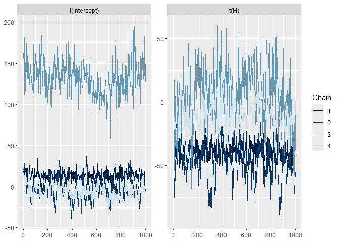

```r
mcmc_trace(draws_final,
           pars = intersect(c('Intercept', 'H'), global_params),
           transformations = unwrap_circular_deg)
```

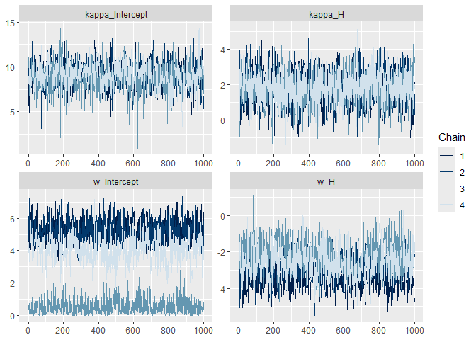

```r
mcmc_trace(draws_final,
           pars = intersect(c('kappa_Intercept', 'kappa_H', 'w_Intercept', 'w_H'), global_params))
```

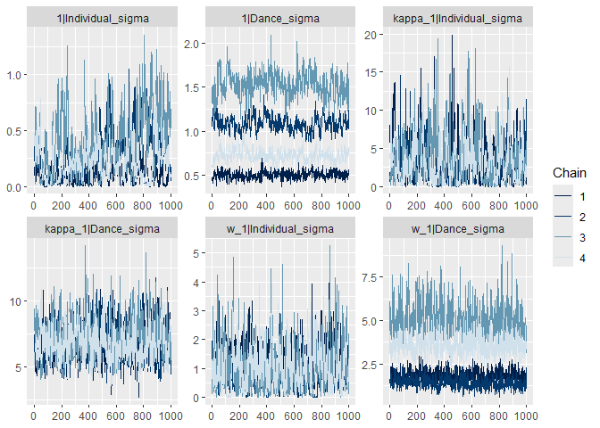

```r
mcmc_trace(draws_final,
           pars = grep('_sigma$', global_params, value = TRUE))
```

Check the $\hat{R}$ values (convergence is indicated by $\hat{R}<1.01$). Disagreement between chains in `Intercept`, `H` or the `w_` parameters would indicate label switching.

```r
azsum_fixed = az$summary(idata,
                         var_names = global_params,
                         circ_var_names = intersect(c("Intercept", "H"), global_params)
)
print(azsum_fixed[, c(1, 3, 4, 7, 9)], digits = 3)
```

```
##                            mean hdi_3% hdi_97% ess_bulk r_hat
## Intercept                 0.328 -0.402   2.609        6  1.81
## H                        -0.398 -1.142   0.491        6  1.83
## kappa_Intercept           8.941  6.461  11.492     1263  1.00
## kappa_H                   1.793  0.145   3.509     2925  1.00
## w_Intercept               3.750  0.001   6.061        6  1.79
## w_H                      -2.749 -4.367  -0.993       13  1.21
## 1|Individual_sigma        0.242  0.000   0.663       12  1.26
## 1|Dance_sigma             0.960  0.430   1.646        5  2.83
## kappa_1|Individual_sigma  3.263  0.002   7.873      328  1.01
## kappa_1|Dance_sigma       6.901  4.514   9.347      473  1.02
## w_1|Individual_sigma      1.039  0.001   2.131       29  1.10
## w_1|Dance_sigma           2.968  0.735   5.581        5  2.27
```

```r
divs = reticulate::py_get_item(idata$sample_stats, 'diverging')$values
print(paste('Divergent transitions per chain:', paste(rowSums(divs), collapse = ', ')))
```

```
## [1] "Divergent transitions per chain: 0, 1, 0, 0"
```

# Extract predictions

To look at the model estimates in context and compare the predictions with the data, we need to extract and summarise the draws. The posterior can be summarised by its quantiles: `quantile(x, probs = c(0.025, 0.975))` identifies the interval containing the central $95\%$ of draws for `x`.

On a circular scale the bounds between which quantiles should be counted are not clearly defined. We centre each set of draws on its circular median before calculating quantiles, so that the boundary falls far from the bulk of the estimates.

```r
#A function to find the circular median in (-pi, pi)
MedCDraws = function(x,
                     templ = 'none', #assumes radians
                     medn = 1) #take the 1st median
{
  median.circular( circular(x = mod_circular(x),
                            template = templ)
                                           )[medn]
}
#A function to report circular quantiles in degrees, centred on the circular median
QDegDraws = function(x,
                     probs = c(0.5, 0.025, 0.975))
{
  mx = as.numeric(MedCDraws(x))
  round(deg(
    quantile(mod_circular(x - mx), probs = probs) + mx
  ))
}
#A function to report linear quantiles
QDraws = function(x,
                  probs = c(0.5, 0.025, 0.975),
                  digits = 2)
{
  round(quantile(x, probs = probs),
        digits = digits)
}
#Bimodality index: 0 for unimodal (w = 0 or 1), 1 for axially symmetric (w = 0.5)
Bimodality = function(w)
{
  1 - abs(2 * w - 1)
}
#Linear predictors for a condition, given the prefix of the parameter ('' for mu, 'kappa_' or 'w_')
#and optional individual and dance levels
LinPred = function(prefix, cnd, i = NULL, d = NULL)
{
  eta = GetDraws(paste0(prefix, 'Intercept'))
  for(eff in cond_effs[[cnd]])
  {
    eta = eta + GetDraws(paste0(prefix, eff))
  }
  if(!is.null(i)){eta = eta + GetDraws(paste0(prefix, '1_Individual_', i))}
  if(!is.null(d)){eta = eta + GetDraws(paste0(prefix, '1_Dance_', d))}
  eta
}
#Predicted mu, kappa and w for a condition (optionally for an individual and dance)
#relabelled by the population-level primary mode of that condition (flip: cos(mu) < 0),
#which leaves the mixture density unchanged
Predict = function(cnd, i = NULL, d = NULL)
{
  flip = cos(LinPred('', cnd)) < 0
  mu = mod_circular(LinPred('', cnd, i, d))
  kappa = softplus(LinPred('kappa_', cnd, i, d))
  w = if(is_mixture){plogis(LinPred('w_', cnd, i, d))}else{rep(1, length(mu))}
  list(mu = ifelse(flip, mod_circular(mu + pi), mu),
       kappa = kappa,
       w = ifelse(flip, 1 - w, w),
       flip = flip)
}
```

## Population-level predictions for each condition

In the plots below, each mode ($\mu_1 = \mu$ and $\mu_2 = \mu + \pi$) is shown as a separate mean vector of length $A_1(\kappa)$, with line width (and contour opacity) scaled by its weight ($w$ and $1 - w$), following `PlotMV_circMLE` in `HS_functions.R`: line width $5w$ for individuals and populations ($2w$ for dances), with a minimum of 0.5 so that minor modes remain visible.

```r
pop_draws = lapply(setNames(conds, conds), Predict)

#check for relabelling
for(cnd in conds)
{
  print(paste0(cnd, ': proportion of draws relabelled = ',
               round(mean(pop_draws[[cnd]]$flip), 3)))
}
```

```
## [1] "vertical: proportion of draws relabelled = 0.249"
## [1] "horizontal: proportion of draws relabelled = 0.25"
```

```r
pred_table = do.call(rbind,
                     lapply(conds,
                            function(cnd)
                            {
                              pd = pop_draws[[cnd]]
                              mq = QDegDraws(pd$mu)
                              kq = QDraws(pd$kappa)
                              rq = QDraws(A1(pd$kappa), digits = 3)
                              wq = QDraws(pd$w, digits = 3)
                              bq = QDraws(Bimodality(pd$w), digits = 3)
                              data.frame(condition = cnd,
                                         mu_median = mq[1], mu_lower = mq[2], mu_upper = mq[3],
                                         kappa_median = kq[1], kappa_lower = kq[2], kappa_upper = kq[3],
                                         rho_median = rq[1], rho_lower = rq[2], rho_upper = rq[3],
                                         w_median = wq[1], w_lower = wq[2], w_upper = wq[3],
                                         B_median = bq[1], B_lower = bq[2], B_upper = bq[3],
                                         row.names = NULL)
                            }
                     )
)
print(pred_table)
```

```
##    condition mu_median mu_lower mu_upper kappa_median kappa_lower kappa_upper
## 1   vertical        -5      -71       22         8.99        6.13       11.45
## 2 horizontal       -29      -66       -5        10.75        7.84       13.30
##   rho_median rho_lower rho_upper w_median w_lower w_upper B_median B_lower
## 1      0.943     0.914     0.955    0.989   0.239   0.998    0.022   0.003
## 2      0.952     0.934     0.962    0.865   0.572   0.954    0.271   0.091
##   B_upper
## 1   0.964
## 2   0.849
```

## Extracting individual- and dance-specific predictions

This section combines population-level and group-level parameters to compute the posterior predictions for each individual in each condition in which it danced, and for each dance in the condition in which it was performed.

**Processing Workflow**

- **Linear Combination Reconstruction**: The population-level effects are recombined with the individual-level (and dance-level) deviations to reconstruct the specific direction ($\mu$), consistency ($\kappa$) and mixture weight ($w$), using `Predict`.
- **Nested Storage Architecture**: The raw vectors are assigned to nested lists (`individual_draws`, `dance_draws`) to preserve the entire distribution, and point-estimate summaries (medians) are stored in matrices (`mu_id`, `kappa_id`, `w_id`) for the conditions in which each individual danced (otherwise `NA`).

```r
# Setup containers for summary statistics
mu_id = kappa_id = w_id = matrix(NA,
                                 nrow = n_ind,
                                 ncol = length(conds),
                                 dimnames = list(NULL, conds))

# Structure: individual_draws[[i]]$mu$vertical
individual_draws = vector("list", n_ind)

for(i in id_tab$Individual_nr) {
  individual_draws[[i]] = list(mu = list(), kappa = list(), w = list())
  for(cnd in conds[id_cond[id_tab$Individual_nr == i, ]])
  {
    pi_c = Predict(cnd, i = i)
    individual_draws[[i]]$mu[[cnd]] = pi_c$mu
    individual_draws[[i]]$kappa[[cnd]] = pi_c$kappa
    individual_draws[[i]]$w[[cnd]] = pi_c$w
    mu_id[i, cnd] = MedCDraws(pi_c$mu)
    kappa_id[i, cnd] = median(pi_c$kappa)
    w_id[i, cnd] = median(pi_c$w)
  }
}
```

Each dance was performed in a single condition, so its prediction combines the population, individual and dance-level effects for that condition only.

```r
mu_dance = kappa_dance = w_dance = numeric(n_dance)
dance_draws = vector("list", n_dance)

for(d in dance_tab$Dance_nr)
{
  i = dance_tab$Individual_nr[dance_tab$Dance_nr == d]
  cnd = as.character(dance_tab$condition[dance_tab$Dance_nr == d])
  dance_draws[[d]] = Predict(cnd, i = i, d = d)
  mu_dance[d] = MedCDraws(dance_draws[[d]]$mu)
  kappa_dance[d] = median(dance_draws[[d]]$kappa)
  w_dance[d] = median(dance_draws[[d]]$w)
}
```

### Visualising individual predictions

This section loops through individual bees to plot observed waggle$~$runs against the model’s posterior predictions for each condition. The raw circular data are displayed alongside density contours of the mean vector of each mode, derived from the joint posterior distribution of $\mu$ and $\kappa$ for that individual (primary mode, $\mu_1$, in red-yellow; reverse mode, $\mu_2$, in blue), with opacity scaled by the posterior median weight of each mode. Thin lines show the median estimated mean$~$vectors of the two modes for each dance, and arrows show those for the individual, with line widths scaled by the weight of each mode. Conditions in which an individual did not dance are left blank.

```r
#Plot separate mean vectors for each mode (mu1 = mu, mu2 = mu + pi), each of length A1(kappa),
#with line width scaled by the weight of that mode (as in PlotMV_circMLE: lwd = 5 * weight1)
#lwd is the line width of a fully unimodal mode (w = 1), lwd_min keeps minor modes visible
ModeArrows = function(mu, kappa, w, col, lwd = 5, lwd_min = 0.5, length = 0, alpha = 200/255)
{
  mus = c(mu, mod_circular(mu + pi))
  ws = if(is_mixture){c(w, 1 - w)}else{1}
  for(md in seq_along(ws))
  {
    arrows.circular(
      x = circular(mus[md],
                   units = 'radians',
                   rotation = 'clock',
                   zero = pi/2),
      y = A1(kappa),
      lwd = max(lwd_min, lwd * ws[md]),
      length = length,
      col = adjustcolor(col, alpha.f = alpha)
    )
  }
}
#Plot posterior density contours for the mean vectors of both modes,
#with opacity scaled by the posterior median weight of each mode
ModeContours = function(draws_list, cnd)
{
  w_med = median(draws_list$w[[cnd]])
  Draws2Cont(draws_list,
             alpha = 200/255 * w_med,
             x_string = paste0('sin(mu$', cnd, ') * A1(kappa$', cnd, ')'),
             y_string = paste0('cos(mu$', cnd, ') * A1(kappa$', cnd, ')'))
  if(is_mixture)
  {
    Draws2Cont(draws_list,
               palette = 'Blues 3',
               alpha = 200/255 * (1 - w_med),
               x_string = paste0('-sin(mu$', cnd, ') * A1(kappa$', cnd, ')'),
               y_string = paste0('-cos(mu$', cnd, ') * A1(kappa$', cnd, ')'))
  }
}
```

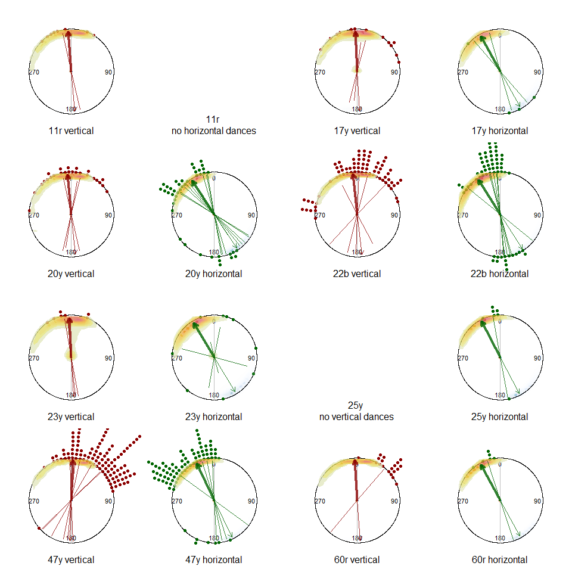

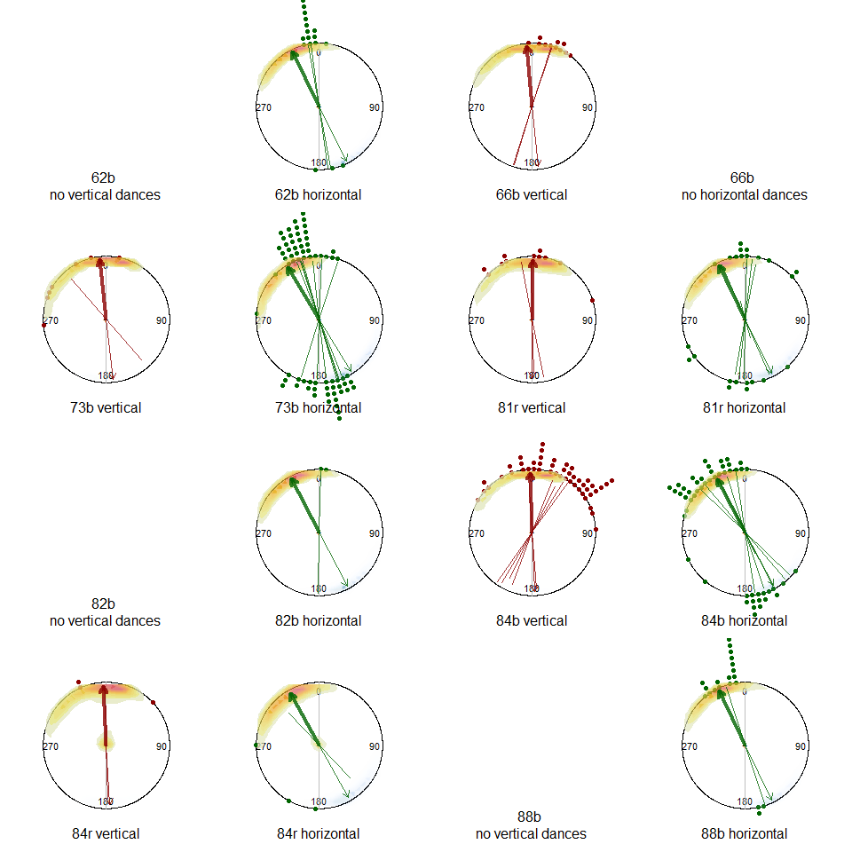

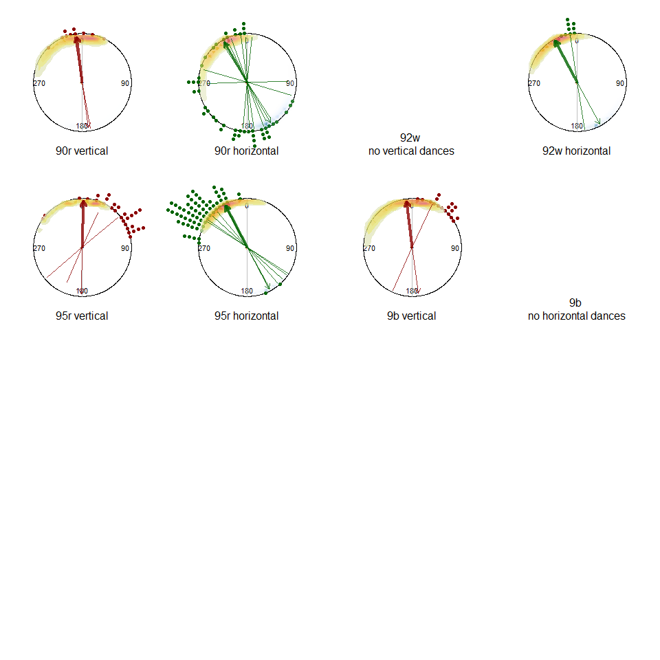

```r
par(pty = 's')
par(mar = c(0,0,0,0),
    mfrow = c(4,4) )
for(i in id_tab$Individual_nr)
{
  indiv = as.character(id_tab$ID[id_tab$Individual_nr == i])
  for(cnd in conds)
  {
    dt_ic = subset(hd,
                   Individual_nr == i &
                     condition %in% cnd)
    if(!nrow(dt_ic))
    {
      plot.new()
      mtext(text = paste(indiv, '\nno', cnd, 'dances'),
            side = 1,
            line = -2)
      next
    }
    with(dt_ic,
    {
      PCfun(angles = angle_deg,
           col = cond_cols[[cnd]],
           plot_rho = FALSE,
           title = paste(indiv, cnd))
      }
    )
    ModeContours(individual_draws[[i]], cnd)
    #dance estimates
    for(d in unique(dt_ic$Dance_nr))
    {
      ModeArrows(mu_dance[d], kappa_dance[d], w_dance[d],
                 col = cond_cols[[cnd]], lwd = 2)
    }
    #individual estimate
    ModeArrows(mu_id[i, cnd], kappa_id[i, cnd], w_id[i, cnd],
               col = cond_cols[[cnd]], lwd = 5, length = 0.1/1.25, alpha = 0.8)
  }
}
```

## Plot population level predictions

### Visualising population-level circular predictions

This section plots all waggle runs in each condition, the median estimated mean$~$vectors of both modes for each individual (thin lines), posterior density contours for the population mean vectors of both modes, and the population’s median estimated mean$~$vectors (thick arrows).

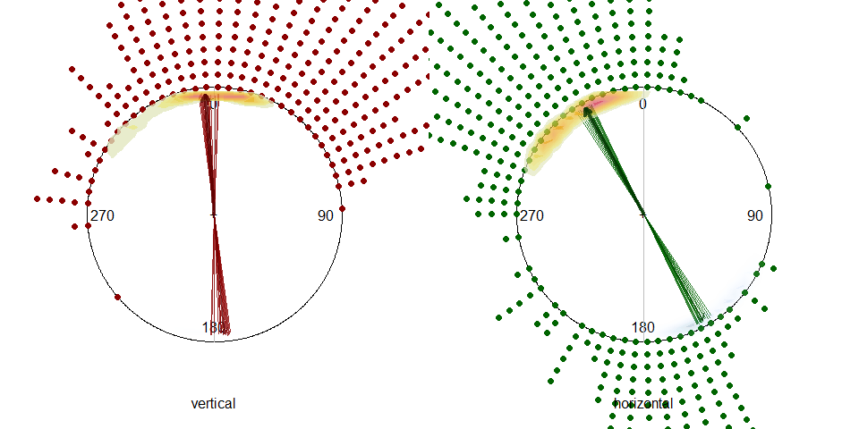

```r
par(pty = 's')
par(mfrow = c(1,2), mar = c(0,0,0,0))

for(cnd in conds)
{
  with(subset(hd, condition %in% cnd), {
    PCfun(angles = angle_deg, col = cond_cols[[cnd]], shrink = 1.5, plot_rho = FALSE,
          title = cnd)
  })

  for(i in id_tab$Individual_nr[id_cond[, cnd]]) {
    ModeArrows(mu_id[i, cnd], kappa_id[i, cnd], w_id[i, cnd],
               col = cond_cols[[cnd]], lwd = 2)
  }

  pop_list = list(mu = setNames(list(pop_draws[[cnd]]$mu), cnd),
                  kappa = setNames(list(pop_draws[[cnd]]$kappa), cnd),
                  w = setNames(list(pop_draws[[cnd]]$w), cnd))
  ModeContours(pop_list, cnd)

  ModeArrows(MedCDraws(pop_draws[[cnd]]$mu),
             median(pop_draws[[cnd]]$kappa),
             median(pop_draws[[cnd]]$w),
             col = adjustcolor(cond_cols[[cnd]], offset = c(rep(-0.2,3),0)),
             lwd = 5, length = 0.1/1.25)
}
```

```r
for(cnd in conds)
{
  print(paste(cnd, "primary mode mean direction"))
  print(QDegDraws(pop_draws[[cnd]]$mu))
}
```

```
## [1] "vertical primary mode mean direction"
##   50%  2.5% 97.5%
##    -5   -71    22
## [1] "horizontal primary mode mean direction"
##   50%  2.5% 97.5%
##   -29   -66    -5
```

### Effects of horizontal orientation

The change in each population-level parameter between the vertical and horizontal conditions. Only 12 individuals danced in both conditions, and the model has no individual-level effects of condition, so the change is the same for every individual.

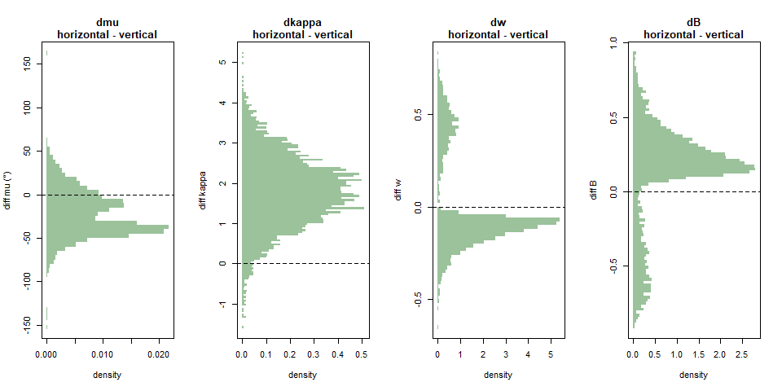

```r
dmu = mod_circular(pop_draws$horizontal$mu - pop_draws$vertical$mu)
dkappa = pop_draws$horizontal$kappa - pop_draws$vertical$kappa
dw = pop_draws$horizontal$w - pop_draws$vertical$w
dB = Bimodality(pop_draws$horizontal$w) - Bimodality(pop_draws$vertical$w)

par(mfrow = c(1,4))
for(nm in c('dmu', 'dkappa', 'dw', 'dB'))
{
  x = switch(nm, dmu = deg(dmu), dkappa = dkappa, dw = dw, dB = dB)
  VertHist(data = x,
           main = paste0('\n', nm, '\nhorizontal - vertical'),
           ylab = switch(nm, dmu = 'diff mu (°)', dkappa = 'diff kappa', dw = 'diff w', dB = 'diff B'),
           col = adjustcolor(cond_cols$horizontal, alpha.f = 100/255),
           cex.axis = 0.7)
  abline(h = 0, lty = 2)
}
```

```r
effect_table = data.frame(
  effect = c('dmu (°)', 'dkappa', 'drho', 'dw', 'dB'),
  rbind(QDegDraws(dmu),
        QDraws(dkappa),
        QDraws(A1(pop_draws$horizontal$kappa) - A1(pop_draws$vertical$kappa), digits = 3),
        QDraws(dw, digits = 3),
        QDraws(dB, digits = 3)),
  p_greater_than_0 = round(c(mean(dmu > 0), mean(dkappa > 0),
                             mean(A1(pop_draws$horizontal$kappa) > A1(pop_draws$vertical$kappa)),
                             mean(dw > 0), mean(dB > 0)), 3),
  check.names = FALSE
)
print(effect_table)
```

```
##    effect     50%    2.5%  97.5% p_greater_than_0
## 1 dmu (°) -27.000 -67.000 32.000            0.198
## 2  dkappa   1.790  -0.010  3.540            0.975
## 3    drho   0.010   0.000  0.026            0.975
## 4      dw  -0.091  -0.333  0.596            0.249
## 5      dB   0.189  -0.731  0.669            0.786
```

# Bimodality

**Hypothesis**: horizontal dances are more likely to be bimodal than vertical dances.

Bimodality ($B$) is compared at two levels:

1. **Population level**: $B$ for a typical dance (random effects at zero) in each condition (above, `dB`).
2. **Dance level**: the mean $B$ across the observed dances in each condition, which includes the dance and individual random effects.

## Dance-level bimodality

Posterior median $w$ for each dance against the observed proportion of its waggle runs within 90° of the population primary mode for its condition. Dances near 1 are unimodal towards the primary mode, those near 0 are unimodal but reversed, and those near 0.5 are bimodal.

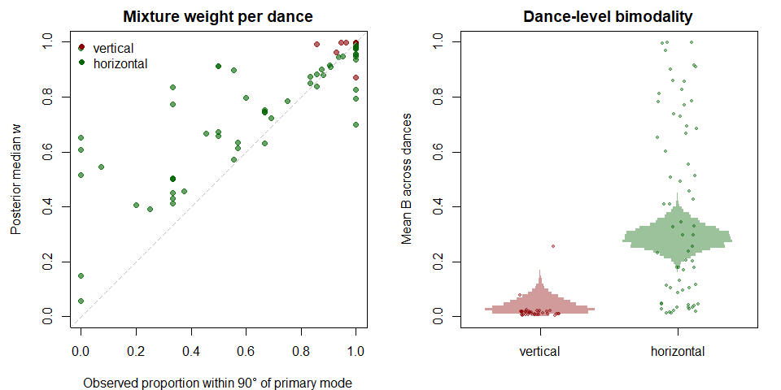

```r
#observed proportion of runs within 90° of the population primary mode
pop_mu_med = sapply(conds, function(cnd){MedCDraws(pop_draws[[cnd]]$mu)})
dance_tab = within(dance_tab,
                   {
                     w_med = w_dance[Dance_nr]
                     B_med = Bimodality(w_dance[Dance_nr])
                     prop_primary = sapply(Dance_nr,
                                           function(d)
                                           {
                                             dt_d = subset(hd, Dance_nr == d)
                                             cnd = as.character(dt_d$condition[1])
                                             mean(cos(dt_d$angle - pop_mu_med[cnd]) > 0)
                                           }
                                           )
                   }
                   )

par(mfrow = c(1,2), pty = 's', mar = c(4,4,2,1))
with(dance_tab,
     {
       plot(x = prop_primary,
            y = w_med,
            xlim = c(0,1), ylim = c(0,1),
            pch = 19,
            col = adjustcolor(unlist(cond_cols[as.character(condition)]), alpha.f = 0.6),
            xlab = 'Observed proportion within 90° of primary mode',
            ylab = 'Posterior median w',
            main = 'Mixture weight per dance')
       abline(a = 0, b = 1, lty = 2, col = 'gray')
       legend('topleft', legend = conds, pch = 19, col = unlist(cond_cols), bty = 'n')
     }
)

#mean B across observed dances in each condition, per draw
B_dance_mean = lapply(setNames(conds, conds),
                      function(cnd)
                      {
                        ds = dance_tab$Dance_nr[dance_tab$condition %in% cnd]
                        rowMeans(sapply(ds, function(d){Bimodality(dance_draws[[d]]$w)}))
                      }
                      )
dB_dance = B_dance_mean$horizontal - B_dance_mean$vertical

B_lim = c(0, 1)
plot(NULL, xlim = c(0.5, 2.5), ylim = B_lim, xaxt = 'n',
     xlab = '', ylab = 'Mean B across dances', main = 'Dance-level bimodality')
axis(1, at = 1:2, labels = conds)
for(j in seq_along(conds))
{
  hst = hist(B_dance_mean[[conds[j]]], breaks = seq(0, 1, by = 0.01), plot = FALSE)
  dens = 0.4 * hst$density / max(hst$density)
  rect(xleft = j - dens, xright = j + dens,
       ybottom = head(hst$breaks, -1), ytop = hst$breaks[-1],
       col = adjustcolor(cond_cols[[conds[j]]], alpha.f = 100/255), border = NA)
}
#dance medians
with(dance_tab,
     points(x = as.numeric(condition) + runif(length(B_med), -0.15, 0.15),
            y = B_med,
            pch = 19, cex = 0.5,
            col = adjustcolor(unlist(cond_cols[as.character(condition)]), alpha.f = 0.4))
)
```

```r
bimodality_table = data.frame(
  measure = c('B vertical (population)', 'B horizontal (population)', 'dB (population)',
              'B vertical (mean of dances)', 'B horizontal (mean of dances)', 'dB (mean of dances)'),
  rbind(QDraws(Bimodality(pop_draws$vertical$w), digits = 3),
        QDraws(Bimodality(pop_draws$horizontal$w), digits = 3),
        QDraws(dB, digits = 3),
        QDraws(B_dance_mean$vertical, digits = 3),
        QDraws(B_dance_mean$horizontal, digits = 3),
        QDraws(dB_dance, digits = 3)),
  check.names = FALSE
)
print(bimodality_table)
```

```
##                         measure   50%   2.5% 97.5%
## 1       B vertical (population) 0.022  0.003 0.964
## 2     B horizontal (population) 0.271  0.091 0.849
## 3               dB (population) 0.189 -0.731 0.669
## 4   B vertical (mean of dances) 0.038  0.010 0.110
## 5 B horizontal (mean of dances) 0.289  0.211 0.380
## 6           dB (mean of dances) 0.249  0.132 0.352
```

```r
print(paste0('P(dB > 0), population level: ', round(mean(dB > 0), 3)))
```

```
## [1] "P(dB > 0), population level: 0.786"
```

```r
print(paste0('P(dB > 0), mean of dances: ', round(mean(dB_dance > 0), 3)))
```

```
## [1] "P(dB > 0), mean of dances: 1"
```

## Visualising consistency predictions

The posterior distributions of the concentration ($\kappa$) shared by both modes in each condition.

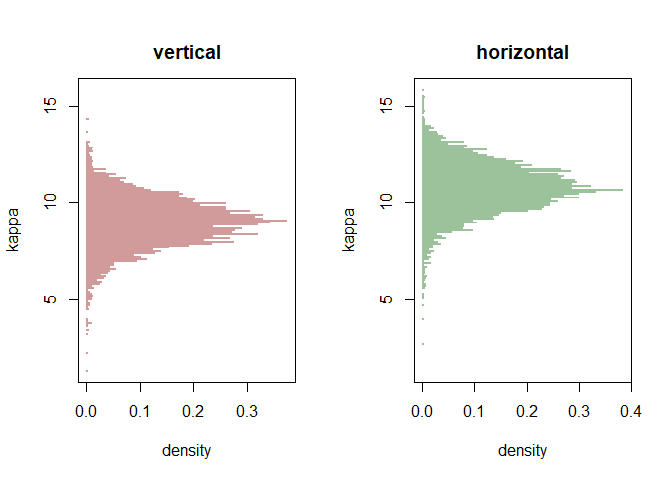

```r
par(mfrow = c(1,2))
kappa_lim = range(unlist(lapply(pop_draws, `[[`, 'kappa')))

for(cnd in conds)
{
  VertHist(data = pop_draws[[cnd]]$kappa,
           main = paste0('\n', cnd),
           ylab = 'kappa',
           ylim = kappa_lim,
           col = adjustcolor(cond_cols[[cnd]], alpha.f = 100/255),
           cex.axis = 0.7)
}
```

```r
print(pred_table[, c('condition', 'kappa_median', 'kappa_lower', 'kappa_upper')])
```

```
##    condition kappa_median kappa_lower kappa_upper
## 1   vertical         8.99        6.13       11.45
## 2 horizontal        10.75        7.84       13.30
```

## Variation across individuals and dances

The scales of the individual- and dance-level random effects. Offsets in $\mu$ are Normal, so their scales are standard deviations in radians (converted here to degrees); those for $\kappa$ and $w$ are standard deviations on the softplus and logit scales.

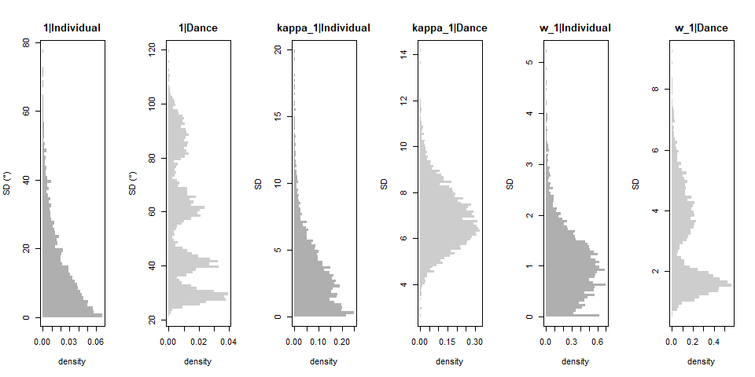

```r
sigma_params = grep('_sigma$', global_params, value = TRUE)
par(mfrow = c(1, length(sigma_params)))
for(sp in sigma_params)
{
  is_mu = !grepl('^kappa_|^w_', sp)
  VertHist(data = if(is_mu){deg(draws_final[[sp]])}else{draws_final[[sp]]},
           main = paste0('\n', gsub('_sigma', '', sp)),
           ylab = if(is_mu){'SD (°)'}else{'SD'},
           col = adjustcolor(if(grepl('Dance', sp)){'gray50'}else{'gray20'}, alpha.f = 100/255),
           cex.axis = 0.7)
}
```

```r
sigma_table = do.call(rbind,
                      lapply(sigma_params,
                             function(sp)
                             {
                               is_mu = !grepl('^kappa_|^w_', sp)
                               q = if(is_mu){QDraws(deg(draws_final[[sp]]), digits = 1)}else{QDraws(draws_final[[sp]])}
                               data.frame(parameter = sp,
                                          units = if(is_mu){'degrees'}else{'link scale'},
                                          median = q[1], lower = q[2], upper = q[3],
                                          row.names = NULL)
                             }
                      )
)
print(sigma_table)
```

```
##                  parameter      units median lower upper
## 1       1|Individual_sigma    degrees  10.20  0.40 46.20
## 2            1|Dance_sigma    degrees  51.70 25.60 97.40
## 3 kappa_1|Individual_sigma link scale   2.71  0.12  9.92
## 4      kappa_1|Dance_sigma link scale   6.78  4.58  9.75
## 5     w_1|Individual_sigma link scale   0.97  0.03  2.63
## 6          w_1|Dance_sigma link scale   2.57  1.01  6.28
```

Dances whose mean direction differs from their individual’s by more than 90° are those for which the model must trade off a drift in direction against a reversal (low $w$).

```r
dance_offsets = sapply(dance_tab$Dance_nr,
                       function(d){median(abs(deg(draws_final[[paste0('1_Dance_', d)]])))})
print(paste('Dances with median |offset| > 90°:', sum(dance_offsets > 90), 'of', n_dance))
```

```
## [1] "Dances with median |offset| > 90°: 1 of 99"
```

```r
print(paste('Dances with median |offset| > 45°:', sum(dance_offsets > 45), 'of', n_dance))
```

```
## [1] "Dances with median |offset| > 45°: 15 of 99"
```

# Model comparison

Leave-one-out cross-validation (LOO-CV) for each waggle run, comparing the models fitted in `HS_circGLMM_mixture_lowel.ipynb`:

0. Unimodal: condition affects mean direction and concentration only.
1. Bimodal, same mixing: dances may be bimodal, equally often in both conditions.
2. Bimodal, condition-dependent mixing.

```r
model_files = c('Unimodal' = 'HS_lowel_VH_0_unimodal.nc',
                'Bimodal, same mixing' = 'HS_lowel_VH_1_axial_w1.nc',
                'Bimodal, condition-dependent mixing' = 'HS_lowel_VH_2_axial_wH.nc')
model_files = file.path(params$model_dir, model_files)
names(model_files) = c('Unimodal', 'Bimodal, same mixing', 'Bimodal, condition-dependent mixing')
model_files = model_files[file.exists(model_files)]
#keep the LOO results as Python objects, so they can be passed back to arviz
az_py = reticulate::import("arviz", convert = FALSE)
loo_list = lapply(model_files,
                  function(f)
                  {
                    az_py$loo(az_py$from_netcdf(f))
                  }
                  )
comparison = reticulate::py_to_r(az_py$compare(reticulate::dict(loo_list), ic = 'loo'))
print(comparison[, c('rank', 'elpd_loo', 'p_loo', 'elpd_diff', 'weight', 'se', 'dse', 'warning')],
      digits = 3)
```

```
##                                     rank elpd_loo p_loo elpd_diff weight   se
## Bimodal, condition-dependent mixing    0     -602   201      0.00 0.9114 33.1
## Bimodal, same mixing                   1     -605   203      3.11 0.0465 33.6
## Unimodal                               2     -788   175    186.08 0.0420 41.0
##                                      dse warning
## Bimodal, condition-dependent mixing  0.0    TRUE
## Bimodal, same mixing                 2.6    TRUE
## Unimodal                            26.5    TRUE
```

```r
for(nm in names(loo_list))
{
  k = reticulate::py_to_r(loo_list[[nm]]$pareto_k$values)
  print(paste0(nm, ': ', sum(k > 0.7), ' of ', length(k), ' waggle runs with Pareto k > 0.7'))
}
```

```
## [1] "Unimodal: 76 of 938 waggle runs with Pareto k > 0.7"
## [1] "Bimodal, same mixing: 52 of 938 waggle runs with Pareto k > 0.7"
## [1] "Bimodal, condition-dependent mixing: 44 of 938 waggle runs with Pareto k > 0.7"
```

# Appendix

## Plot individual and dance effects

### Mean angle

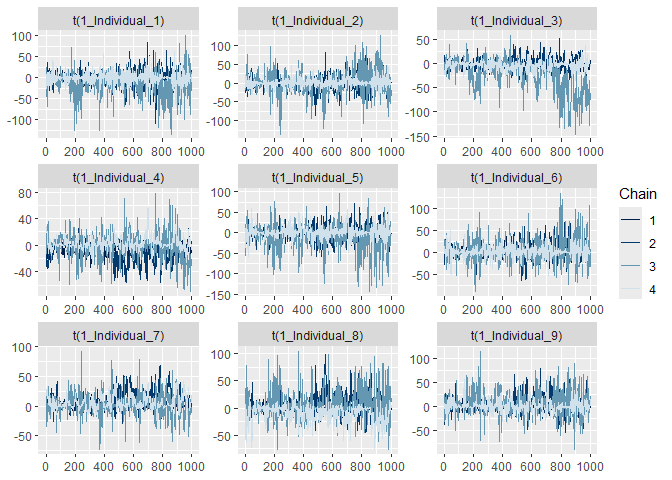

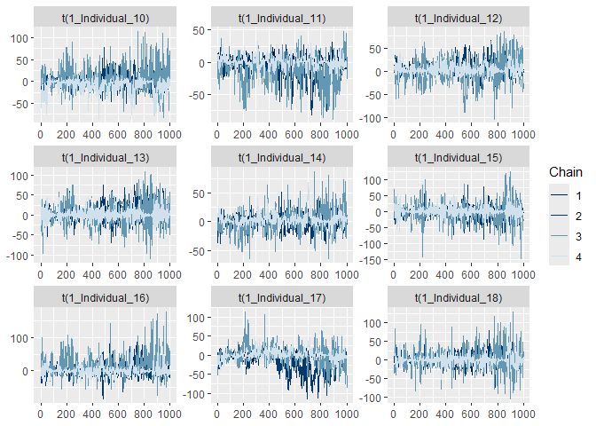

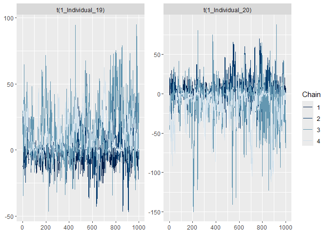

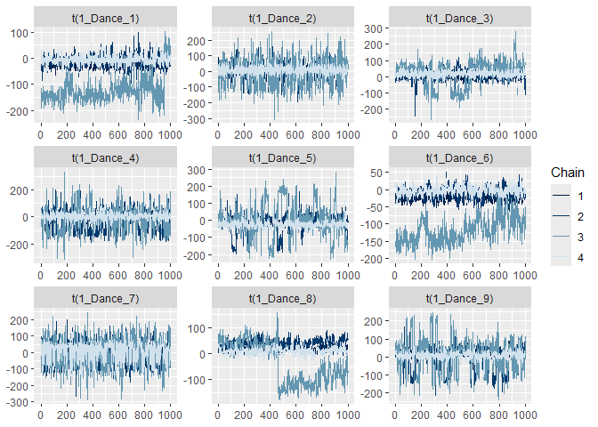

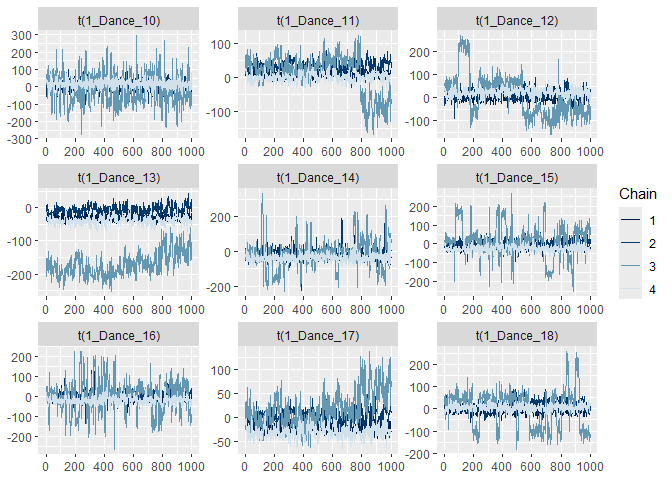

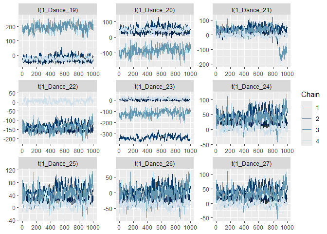

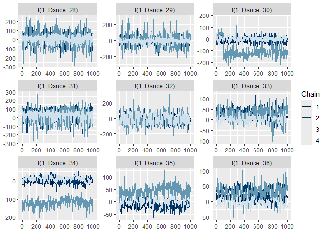

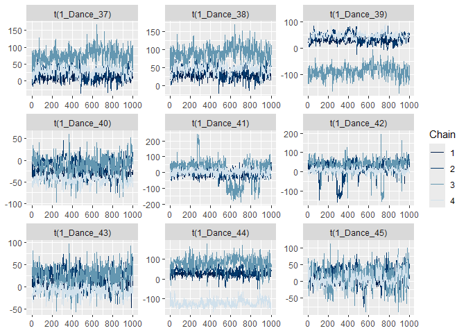

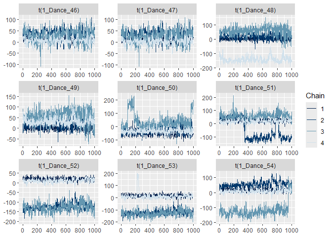

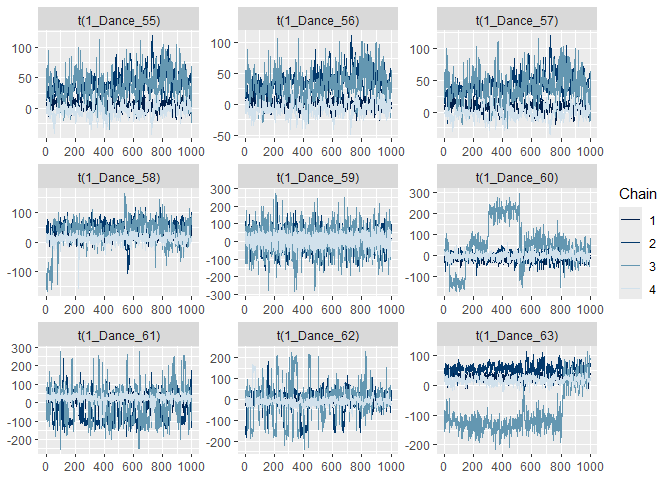

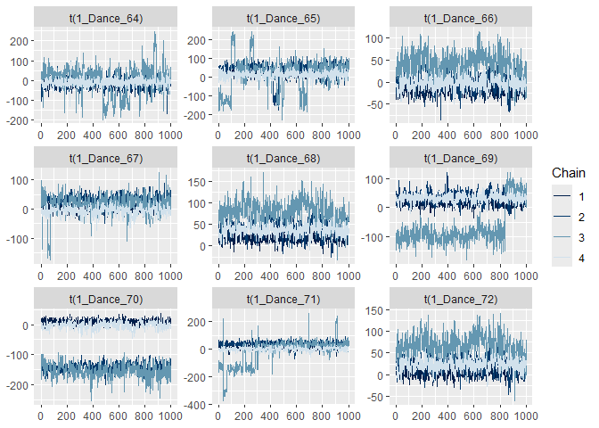

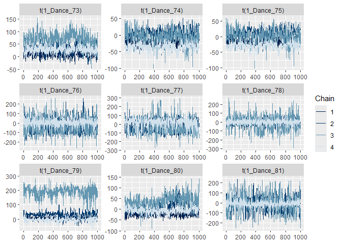

[2 more figures not shown]

```r
plt_panels = 9
for(base in c("1_Individual_", "1_Dance_"))
{
  n_lvl = if(grepl('Dance', base)){n_dance}else{n_ind}
  for(id in 0:(ceiling(n_lvl/plt_panels)-1))
  {
    # Calculate the specific range of indices for this page
    start_idx = (id * plt_panels) + 1
    end_idx   = min((id + 1) * plt_panels, n_lvl)
    plt = mcmc_trace(draws_final,
                     pars = paste0(base,
                                   start_idx:end_idx),
                     facet_args = list(ncol = 3,
                                       nrow = 3),
                     transformations = function(x){deg(x)}
    )
    print(plt)
  }
}
```

### Concentration and mixture weight

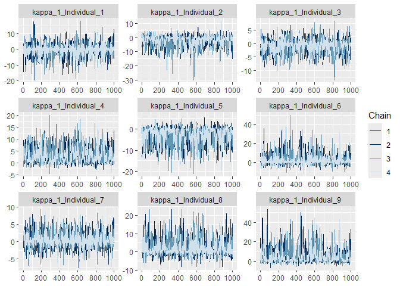

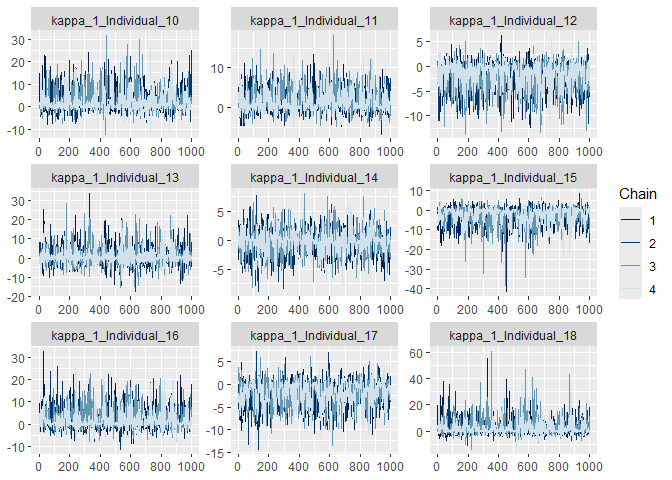

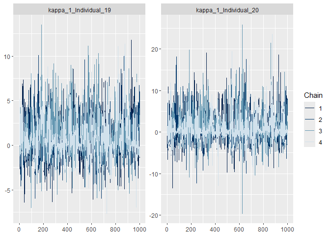

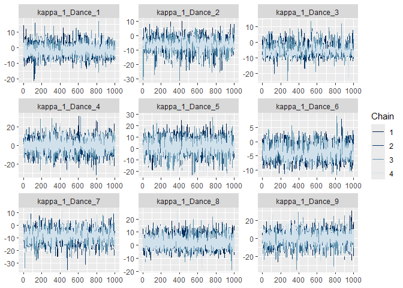

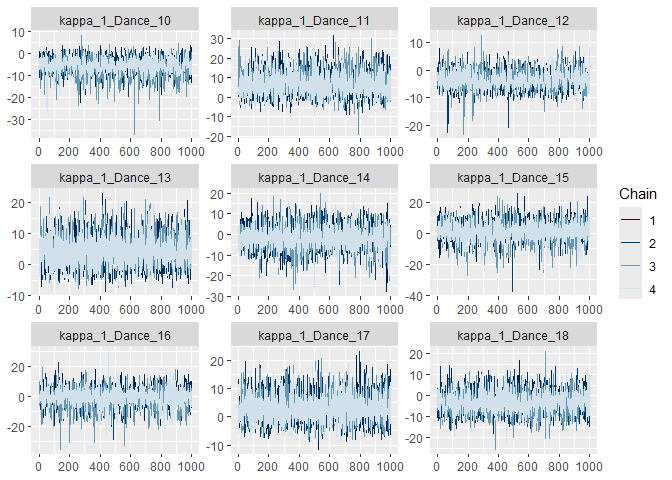

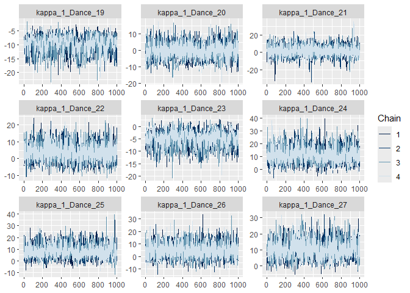

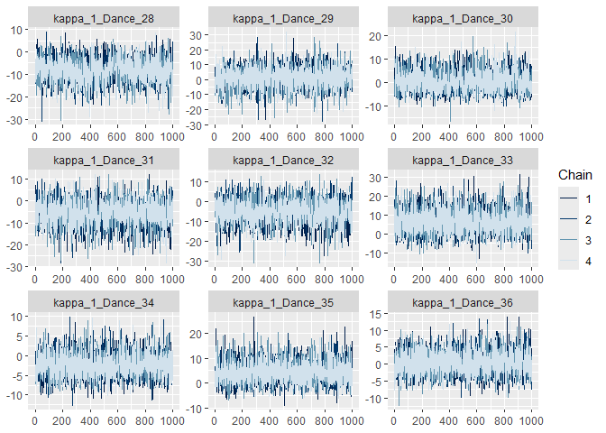

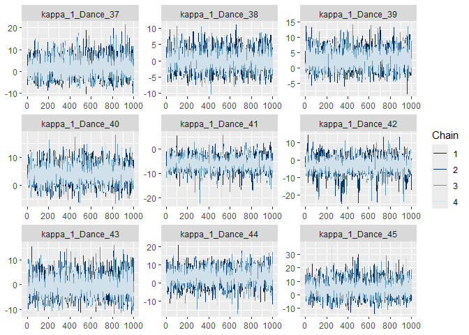

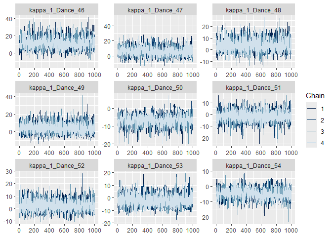

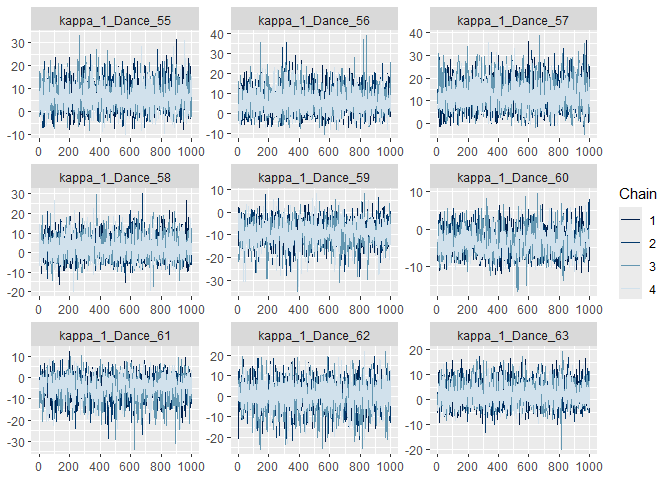

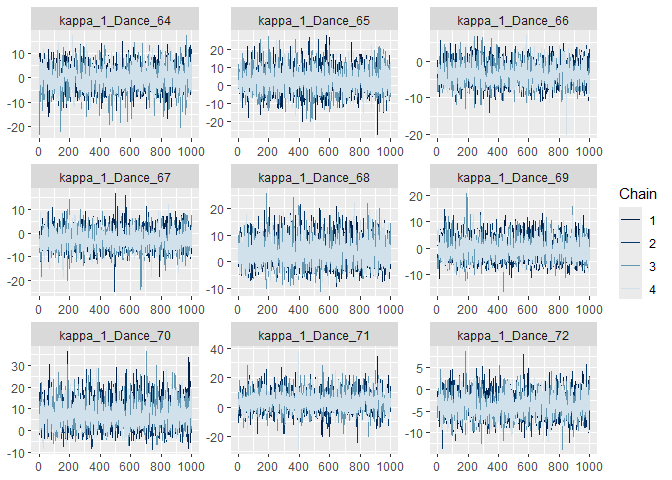

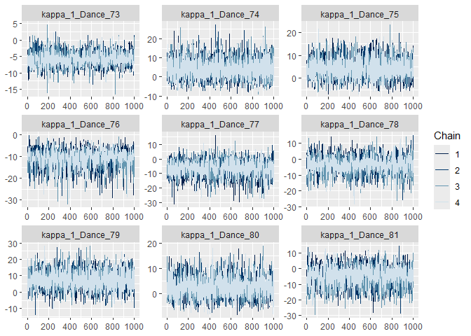

[16 more figures not shown]

```r
plt_panels = 9
for(base in c(paste0("kappa_", c("1_Individual_", "1_Dance_")),
              if(is_mixture){paste0("w_", c("1_Individual_", "1_Dance_"))}))
{
  n_lvl = if(grepl('Dance', base)){n_dance}else{n_ind}
  for(id in 0:(ceiling(n_lvl/plt_panels)-1))
  {
    # Calculate the specific range of indices for this page
    start_idx = (id * plt_panels) + 1
    end_idx   = min((id + 1) * plt_panels, n_lvl)
    plt = mcmc_trace(draws_final,
                     pars = paste0(base, start_idx:end_idx),
                     facet_args = list(ncol = 3, nrow = 3)
    )
    print(plt)
  }
}
```